# Temperature Analysis

Joseph

9/15/2020

Let’s load the libraries

# Climate change and temperature anomalies

With the year 2019 concluding the ‘hotest’ decade since 1850, when global temperature started to be recorded, the year 2020 is subject to the same phenomenon. While scientists are becoming more and more alarmist, the predictions of temperature evolution are inreasingly pessimistic. Let us have a look at the variation of the weather since 1880. For this purpose, we can find data on the *Combined Land-Surface Air and Sea-Surface Water Temperature Anomalies* in the Northern Hemisphere at [NASA’s Goddard Institute for Space Studies](https://data.giss.nasa.gov/gistemp). The [tabular data of temperature anomalies can be found here](https://data.giss.nasa.gov/gistemp/tabledata_v3/NH.Ts+dSST.txt). For each month and year, the dataframe shows the deviation of temperature from the normal (expected).

We run the code below allows to access the file:

```r
weather <-
  vroom::vroom("https://data.giss.nasa.gov/gistemp/tabledata_v3/NH.Ts+dSST.csv", #read data
           skip = 1,
           na = "***")
```

We start by selecting selected the year and the twelve month variables from the `weather` dataset.

```r
tidyweather <- weather %>%
  select("Year","Jan", "Feb", "Mar", "Apr", "May", "Jun", "Jul", "Aug", "Sep","Oct", "Nov", "Dec")
#selecting the columns we need
kable(head(tidyweather,5)) #visalise
```

| Year | Jan | Feb | Mar | Apr | May | Jun | Jul | Aug | Sep | Oct | Nov | Dec |
| --- | --- | --- | --- | --- | --- | --- | --- | --- | --- | --- | --- | --- |
| 1880 | -0.54 | -0.38 | -0.26 | -0.37 | -0.11 | -0.22 | -0.23 | -0.24 | -0.26 | -0.32 | -0.37 | -0.48 |
| 1881 | -0.19 | -0.25 | 0.02 | -0.02 | -0.06 | -0.36 | -0.06 | -0.03 | -0.23 | -0.40 | -0.42 | -0.28 |
| 1882 | 0.22 | 0.22 | 0.00 | -0.36 | -0.32 | -0.38 | -0.37 | -0.14 | -0.17 | -0.53 | -0.32 | -0.42 |
| 1883 | -0.59 | -0.67 | -0.16 | -0.27 | -0.32 | -0.26 | -0.09 | -0.26 | -0.33 | -0.21 | -0.40 | -0.25 |
| 1884 | -0.23 | -0.11 | -0.65 | -0.62 | -0.42 | -0.52 | -0.48 | -0.50 | -0.45 | -0.41 | -0.48 | -0.40 |

Next we convert the dataframe from wide to ‘long’ format using `pivot_longer()` function. Name of the new dataframe is `tidyweather`.The variable containing the name of the month is `month`, and the temperature deviation is `delta`.

```r
tidyweather <- tidyweather %>%
  pivot_longer(cols=2:13,
               names_to="Month",
               values_to = "delta") #transforming to longer format
kable(head(tidyweather, 5)) #visualise
```

| Year | Month | delta |
| --- | --- | --- |
| 1880 | Jan | -0.54 |
| 1880 | Feb | -0.38 |
| 1880 | Mar | -0.26 |
| 1880 | Apr | -0.37 |
| 1880 | May | -0.11 |

```r
tidyweather
```

```
## # A tibble: 1,680 x 3
##     Year Month delta
##    <dbl> <chr> <dbl>
##  1  1880 Jan   -0.54
##  2  1880 Feb   -0.38
##  3  1880 Mar   -0.26
##  4  1880 Apr   -0.37
##  5  1880 May   -0.11
##  6  1880 Jun   -0.22
##  7  1880 Jul   -0.23
##  8  1880 Aug   -0.24
##  9  1880 Sep   -0.26
## 10  1880 Oct   -0.32
## # … with 1,670 more rows
```

The new cleaned dataset has three variables now, one each for

1. year,
2. month, and
3. delta, or temperature deviation.

## Plotting Information

We, as a next step, proceed to plotting the data using a time-series scatter plot with a trendline. To do that, we first created a new variable called `date` in order to ensure that the `delta` values are plot chronologically.

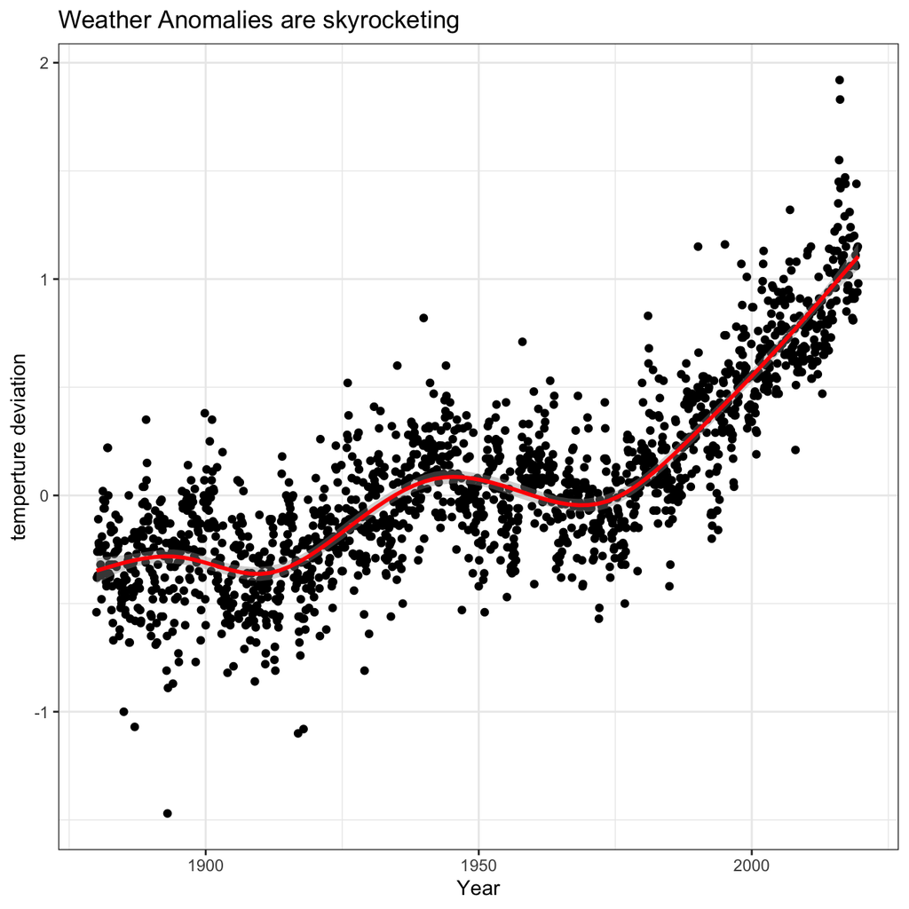

```r
tidyweather <- tidyweather %>%
  mutate(date = ymd(paste(as.character(Year), Month, "1")), #creating dates
         month = month(date, label=TRUE),
         year = year(date))

ggplot(tidyweather, aes(x=date, y = delta))+ #building a plot
  geom_point()+
  geom_smooth(color="red") +
  theme_bw() +
  labs (
    title = "Weather Anomalies are skyrocketing " #adding title
  )+
  ylab("temperture deviation")+
  xlab("Year")
```

Is the effect of increasing temperature more pronounced in some months? We use `facet_wrap()` to produce a seperate scatter plot for each month, again with a smoothing line.

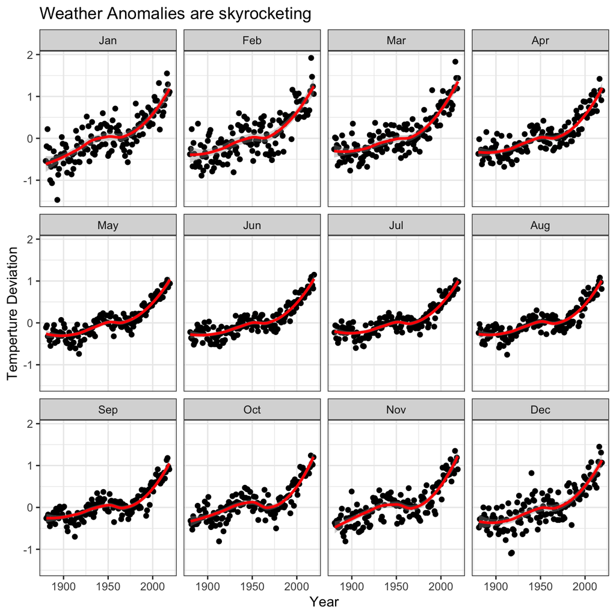

While all the months present some similar curves, some months of the year have a much higher variability than others. This is the case for the northern hemisphere winter months (December, January, February), which shows points that are more distant from the red, smoothing line, therefore implying higher variability in the temperature rise.

Let us now continue our analysis with a different time period to study this historical evolution more in depth. Let’s create a new data frame groupin the data in five time period: 1881-1920, 1921-1950, 1951-1980, 1981-2010 and 2011-present.

```r
comparison <- tidyweather %>%
  select(Year, month, delta) %>%
  filter(Year>= 1881) %>%     #remove years prior to 1881
  #create new variable 'interval', and assign values based on criteria below:
  mutate(interval = case_when(
    Year %in% c(1881:1920) ~ "1881-1920",
    Year %in% c(1921:1950) ~ "1921-1950",
    Year %in% c(1951:1980) ~ "1951-1980",
    Year %in% c(1981:2010) ~ "1981-2010",
    TRUE ~ "2011-present"
  ))
```

Now that we have the `interval` variable, we can create a density plot to study the distribution of monthly deviations (`delta`), grouped by the different time periods we are interested in. Set `fill` to `interval` to group and colour the data by different time periods.

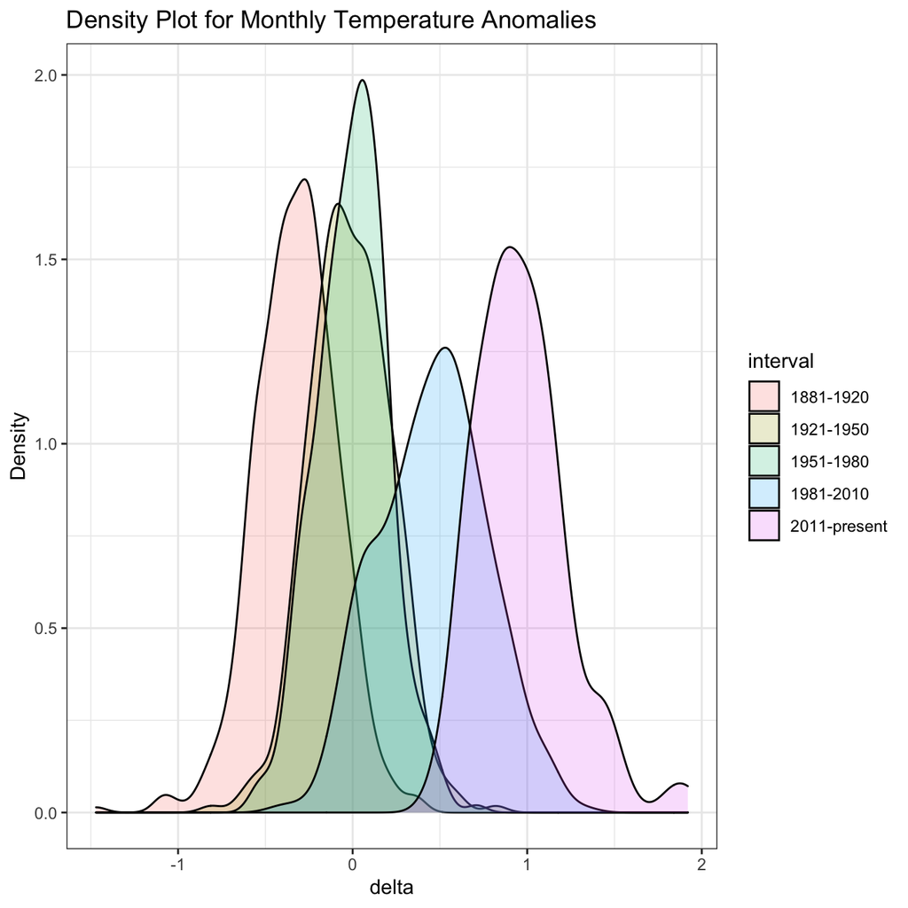

```r
ggplot(comparison, aes(x=delta, fill=interval))+
  geom_density(alpha=0.2) +   #density plot with tranparency set to 20%
  theme_bw() +                #theme
  labs (
    title = "Density Plot for Monthly Temperature Anomalies",
    y     = "Density"         #changing y-axis label to sentence case
  )
```

From this density plot, which displays the average and deviation levels of each decade, it is evident that the last decade (2011-present) is the one presenting the largest positive variation from normal temperatures.

Now, we might be interested in average annual anomalies, so let’s proceed to them instead of monthly data.

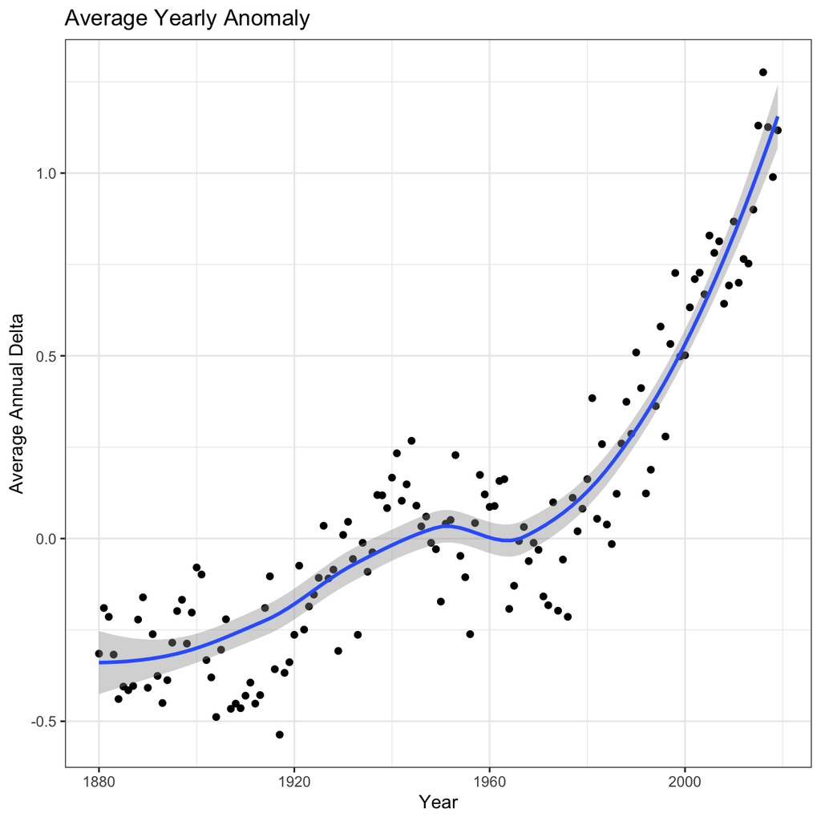

```r
#creating yearly averages
average_annual_anomaly <- tidyweather %>%
  group_by(Year) %>%   #grouping data by Year

  # creating summaries for mean delta
  # use `na.rm=TRUE` to eliminate NA (not available) values
  summarise(annual_average_delta = mean(delta, na.rm=TRUE))

#plotting the data:
ggplot(average_annual_anomaly, aes(x=Year, y= annual_average_delta))+
  geom_point()+

  #Fit the best fit line, using LOESS method
  geom_smooth() +

  #change to theme_bw() to have white background + black frame around plot
  theme_bw() +
  labs (
    title = "Average Yearly Anomaly",
    y     = "Average Annual Delta"
  )
```

## Confidence Interval for `delta`

Finally, let us build a confidence interval displaying the range of variation we can expect at a 95% confidence level. We construct a confidence interval for the average annual delta since 2011, both using a formula and using a bootstrap simulation with the `infer` package.

```r
formula_ci <- comparison %>%

  # choose the interval 2011-present
  filter(interval == "2011-present") %>%
  # calculate necessary statistics for delta
  summarise(
            mean = mean(delta, na.rm=TRUE), # calculate mean
            count = n(), # count
            sd_delta = sd(delta, na.rm=TRUE), #SE
            t_critical = qt(0.975, count-1), #critical value of t-statistics
            lower_ci_95 = mean - (t_critical*sd_delta/sqrt(count)), #lower bound CI
            upper_ci_95 = mean + (t_critical*sd_delta/sqrt(count))) #upper bound CI

formula_ci
```

```
## # A tibble: 1 x 6
##    mean count sd_delta t_critical lower_ci_95 upper_ci_95
##   <dbl> <int>    <dbl>      <dbl>       <dbl>       <dbl>
## 1 0.966   108    0.262       1.98       0.916        1.02
```

```r
point_estimate <- comparison %>%
  filter(interval=="2011-present") %>%
  specify(response = delta) %>% #specifying the variable
  calculate(stat="mean") %>% #specifying the statistics
  dplyr:: pull()

bootstrap_ci <- comparison %>%
  filter(interval=="2011-present") %>% #choosing the interval
  specify(response = delta) %>% #specifying the variable
  hypothesize(null="point", mu=0.2) %>%
  generate(reps=1000, type="bootstrap") %>% #generating bootstrap
  calculate(stat="mean") %>% #calculating the mean
 get_confidence_interval(
    point_estimate = point_estimate,
    level = 0.95, #choosing Cl
   type="se"
 )
bootstrap_ci
```

```
## # A tibble: 1 x 2
##   lower_ci upper_ci
##      <dbl>    <dbl>
## 1    0.916     1.02
```

What we have done is calculated the 95% confidence interval for the population mean for temperature variations. We used two different methods and we came to conclusion that we are 95% confident that the true mean of temperature variations (delta) lies within the interval from 0.915 to 1.02. As the graph have shown, delta is increasing throughout the time, meaning that the population mean is the highest from the whole period for which we have observations.